# Logistic Regression

### 2. Read in and describe the data

```r
alc <- read.csv("data/alc.csv")
colnames(alc)
```

```
##  [1] "X"          "school"     "sex"        "age"        "address"
##  [6] "famsize"    "Pstatus"    "Medu"       "Fedu"       "Mjob"
## [11] "Fjob"       "reason"     "nursery"    "internet"   "guardian"
## [16] "traveltime" "studytime"  "failures"   "schoolsup"  "famsup"
## [21] "paid"       "activities" "higher"     "romantic"   "famrel"
## [26] "freetime"   "goout"      "Dalc"       "Walc"       "health"
## [31] "absences"   "G1"         "G2"         "G3"         "alc_use"
## [36] "high_use"
```

The data contains information about student achievements in secondary eduction of two Portugese schools. It includes students grades, demographic, social and school related features, which were collected via questionnaries. More information at: https://archive.ics.uci.edu/ml/datasets/Student+Performance

### 3. Hypotheses for relationships of alcohol consumption to chosen variables

Personally I would except students with high alcohol consumption (**high_use**) to have worse grades (**G3**), more absences (**absences**), worse health (**health**) and more class failures (**failures**).

### 4. Explore Hypotheses

Let’s explore these hypotheses, first numerically:

```r
table(high_use = alc$high_use, grade = alc$G3)
```

```
##         grade
## high_use  0  2  3  4  5  6  7  8  9 10 11 12 13 14 15 16 17 18
##    FALSE  1  0  1  6  4 15  4 19  3 38 16 54 19 31 15 30  5  7
##    TRUE   1  1  0  1  2  7  2  8  4 26 10 27  7  7  1  8  2  0
```

```r
table(high_use = alc$high_use, absences = alc$absences)
```

```
##         absences
## high_use  0  1  2  3  4  5  6  7  8  9 10 11 12 13 14 16 17 18 19 20 21 26 27
##    FALSE 52 38 42 33 24 16 16  9 14  6  5  2  4  1  1  0  0  1  0  2  1  0  0
##    TRUE  13 13 16  8 12  6  5  3  6  6  2  4  4  1  6  1  1  1  1  0  1  1  1
##         absences
## high_use 29 44 45
##    FALSE  0  0  1
##    TRUE   1  1  0
```

```r
table(high_use = alc$high_use, health = alc$health)
```

```
##         health
## high_use  1  2  3  4  5
##    FALSE 35 28 62 49 94
##    TRUE  11 16 19 18 50
```

```r
table(high_use = alc$high_use, failures = alc$failures)
```

```
##         failures
## high_use   0   1   2   3
##    FALSE 244  12  10   2
##    TRUE   90  12   9   3
```

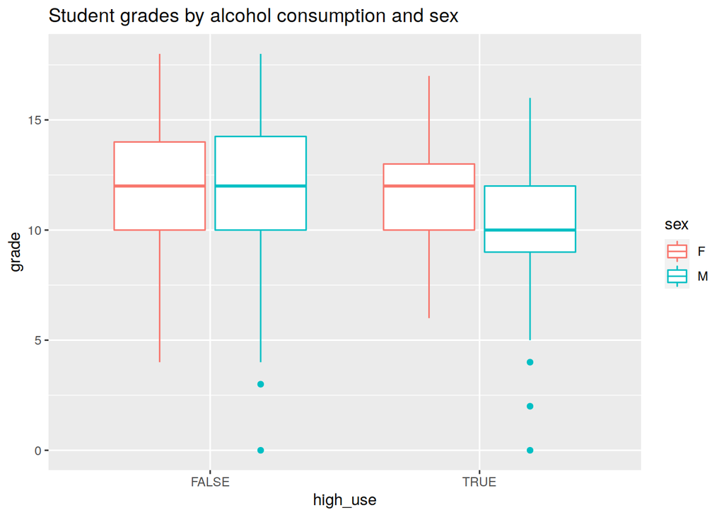

```r
library(ggplot2)
g1 <- ggplot(alc, aes(x = high_use, y = G3, col = sex))
g1 + geom_boxplot() + ylab("grade")   + ggtitle("Student grades by alcohol consumption and sex")
```

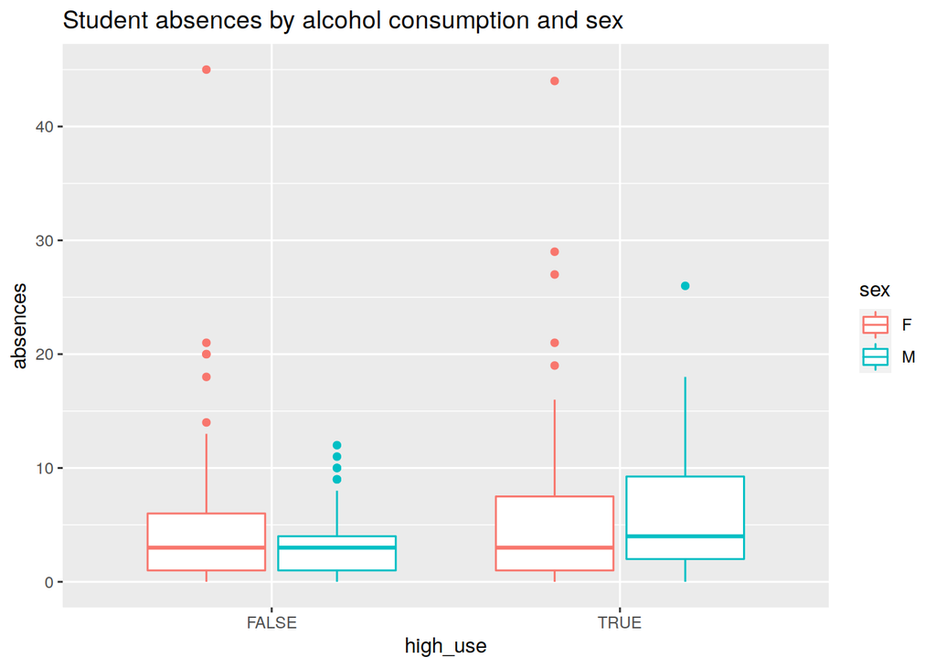

```r
g2 <- ggplot(alc, aes(x = high_use, y = absences, col = sex))
g2 + geom_boxplot() + ylab("absences")   + ggtitle("Student absences by alcohol consumption and sex")
```